```python
import warnings
warnings.filterwarnings('ignore')
```

# Scrapping Digital Library ITB (2.0)

## Pendahuluan

Banyak hal yang terjadi sejak saya melakukan *scraping* website Digital Library ITB (Digilib ITB). Beberapa diantaranya tentang perbaikan website (yang tidak melempar *error* ketika melakukan pencarian data buku), dan adanya akses katalog buku menggunakan protokol OAI-PMH (Open Archive Initiative - Protocol for Metadata Harvesting). Secara sederhana, protokol ini memberikan data XML -- jauh lebih mudah diproses menjadi `dict` ketimbang HTML -- saat kita melakukan *scrapping*. Sebagai contoh, lihat tampilan data di [link ini](https://digilib.itb.ac.id/oai-ristek.php?verb=GetRecord&identifier=12345&metadataPrefix=oai_dc).

## Scrapping

Untuk melakukan *scrapping* kali ini, kita membutuhkan module [`xmltodict`](https://github.com/martinblech/xmltodict) yang memudahkan mengubah data XML menjadi `dict`, dan tentu saja module `request`.

```python
from xmltodict import parse
from urllib.request import urlopen
```

Ada baiknya kita menaruh URL yang akan digunakan dalam scrapping, dan item apa saja yang akan kita ambil.

```python
URL   = "https://digilib.itb.ac.id/oai-ristek.php?verb=GetRecord&identifier={}&metadataPrefix=oai_dc"
items = ['dc:title', 'dc:creator', 'dc:contributor', 'dc:nidn', 'dc:subject', 'dc:date',
         'dc:language', 'dc:type', 'dc:Keyword', 'dc:Institution', 'dc:description']
```

Lalu data buku dapat diambil dengan mudah, salah satunya dengan langkah berikut:

```python
def dictify(num):
    result = {}

    # akses data XML
    with urlopen(URL.format(num)) as f:
        raw = f.read().decode('utf8', 'ignore')

    # lokasi data yang kita inginkan
    data = parse(raw)['OAI-PMH']['GetRecord']['record']['metadata']['oai_dc:dc']

    # catat data
    for i in items:
        result[i] = data[i]

    return result
```

Berikut adalah contoh hasil dari fungsi di atas

```python
dictify(12345)
```

[output not shown]

## Mendownload Data

Saya memerlukan dua module dalam proses ini. Sebenarnya hanya satu, namun module [`tqdm`](https://github.com/tqdm/tqdm) sangat berguna untuk mengetahui sudah sejauh mana proses *download* telah berjalan :D

```python
import pickle
from tqdm import tqdm
```

```python
def batch_download(start_index, end_index, batch_size=100):
    """
    Mengambil data dari start_index sampai end_index.
    Menyimpan setiap batch_size data sebagai sebuah pickle.
    """

    for batch in range(start_index, end_index+1, batch_size):

        # ambil data secara batch
        result = {}
        for num in tqdm(range(batch, batch+batch_size), desc=str(batch)):
            tmp = str(num)
            result[tmp] = dictify(tmp)

        # simpan sebagai sebuah pickle
        with open('pickle_{}'.format(batch), 'wb') as outfile:
            pickle.dump(result, outfile, -1)
```

```python
# Proses ini memerlukan sekitar 4.8 jam
#batch_download(9701, 47600)
```

## Cleaning Data

Selagi mendownload data, saya melihat ada beberapa hal yang dapat diperbaiki. Pertama, beberapa data masih menyimpan tag HTML seperti `<br>`, simbol newline `\n`, tab `\t`, dan sejenisnya, juga inkonsistensi jumlah spasi. Pada data `dc:creator`, terlihat penulisan nama yang dibalik (Last Name, First Name). Lebih lanjut, terkadang ada data NIM yang diletakkan didalamnya.

Dalam proses ini, kita memerlukan tambahan module `re`, yang membantu dalam proses *regular expresion*.

```python
import re
```

Berikut proses cleaning yang akan dilakukan

```python
re_tag = re.compile('<.*?>')

def clean_text(raw):
    "Merapikan teks"

    if len(raw)<=1:
        return None

    text = re.sub(re_tag, '', raw)
    text = ' '.join(text.split())
    return text

def clean_creator(raw):
    "Memformat data creator menjadi (Nama, NIM)"

    nama = raw
    nim = None

    # Perbaiki Nama
    if nama.count(',')==1:
        nama = ' '.join(nama.split(', ')[::-1])

    # Ambil data NIM
    if '(' in nama:
        nama, tmp = nama.split('(', 1)
        nim = re.sub('\D', '', tmp)[:8]
    elif '[' in nama:
        nama, tmp = nama.split('[', 1)
        nim = re.sub('\D', '', tmp)[:8]

    return nama, nim
```

kita letakkan dalam sebuah fungsi

```python
def clean(num):
    with open('pickle_{}'.format(num), 'rb') as f:
        res = pickle.load(f)

    result = {}
    for k,v in res.items():
        cleaned = {}

        for tag,val in v.items():
            if val: cleaned[tag] = clean_text(val)

        cleaned['dc:creator'], cleaned['dc:nim'] = clean_creator(v['dc:creator'])

        result[int(k)] = cleaned.copy()

    with open('clean_{}'.format(num), 'wb') as outfile:
            pickle.dump(result, outfile, -1)
```

Dan kita jalankan

```python
for num in tqdm(range(1, 47600, 100)):
    clean(num)
```

## Bentuk DataFrame

Selanjutnya, kita perlu menyimpan data dalam format yang mudah digunakan. Saya menggunakan `DataFrame`, karena kemampuannya dalam memroses data dan kemampuan *import-export* yang dimiliki

```python
import pandas as pd
```

Selanjutnya kita baca data yang kita miliki

```python
result = {}
for n in range(1, 47600, 100):
    with open('clean_{}'.format(n), 'rb') as outfile:
        result.update(pickle.load(outfile))
```

Selanjutnya, kita akan membentuk `DataFrame` dengan cara

```python
data = pd.DataFrame.from_dict(result, orient='index')
```

Namun, beberapa data (tidak ditampilkan) punya data yang hilang. Kita perlu menghapus baris tanpa `dc:title`

```python
data = data[~data['dc:title'].isna()]
```

```python
data.tail()
```

|  | dc:title | dc:creator | dc:contributor | dc:date | dc:language | dc:type | dc:Institution | dc:description | dc:nim | dc:subject | dc:Keyword | dc:nidn |
| --- | --- | --- | --- | --- | --- | --- | --- | --- | --- | --- | --- | --- |
| 47531 | PENGENDALIAN SISTEM AIR CONDITIONER (AC) BERBA... | Perystito Septhian Siahaan | Drs. Maman Budiman, M.Eng., Ph.D.; | 2020-06-08 16:12:30 | Indonesia | Thesis | INSTITUTE TEKNOLOGI BANDUNG | Penghematan energi merupakan salah satu solusi... | None | FMIPA - Fisika | AC, efesiensi energi, Internet of Things (IoT)... | 0025096601 |
| 47532 | THE RESPONSE OF CYLINDRICAL SANDWICH STRUCTURE... | M Jihad Ummul Quro | Prof. Dr. Ir. Bambang Kismono Hadi;Andi Kuswoy... | 2020-06-08 16:18:36 | Indonesia | Thesis | INSTITUTE TEKNOLOGI BANDUNG | Biomimetics adalah cabang dari ilmu pengetahua... | None | FTMD - Teknik Dirgantara | biomimicry, bambu, beban tekan aksial | 0004096001;0002089203 |
| 47534 | METABOLIT SEKUNDER DARI EKSTRAK BATANG KACANG ... | Farah Hurun'in | Prof. Yana Maolana Syah, MS, Ph.D.; | 2020-06-08 16:34:01 | Indonesia | Thesis | INSTITUTE TEKNOLOGI BANDUNG | Tephrosia vogelii, atau yang dikenal dengan na... | None | FMIPA - Kimia | Isolasi, Tephrosia, Kromatografi, Deguelin, Te... | 0009086203 |
| 47535 | MENGANALISIS FAKTOR-FAKTOR YANG MEMPENGARUHI N... | Chyntia Angelina | Dr. Raden Aswin Rahadi, S.T., M.B.A.; | 2020-06-08 18:27:19 | Indonesia | Thesis | INSTITUTE TEKNOLOGI BANDUNG | Indonesia sedang menuju ke sistem ekonomi digi... | None | Sekolah Bisnis dan Manajemen | Sistem Pembayaran Elektronik, E-wallet, Niat p... | 0008088005 |
| 47536 | PENGHANCURAN NILAI BERSAMA DI GRUP DISKUSI UNT... | Aulia Fadlillah Puteri S. | Nila Armelia Windasari, S.A., M.B.A., Ph.D.; | 2020-06-08 18:51:33 | Indonesia | Thesis | INSTITUTE TEKNOLOGI BANDUNG | Wanita yang memiliki anak kecil atau balita ce... | None | Sekolah Bisnis dan Manajemen | Grop diskusi ibu, faktor disinhibisi online, p... | NaN |

## Analisis Deskriptif

Setelah melakukan proses panjang di atas, ada baiknya kita melihat hasil pekerjaan yang telah dilakukan. Kali ini, saya menggunakan module `missingno` untuk melihat isi `data` secara umum

```python
import missingno as msno
```

Mengecek banyak data yang kosong (`None`) dapat dilihat dengan cara berikut (data kosong ditandai oleh warna putih)

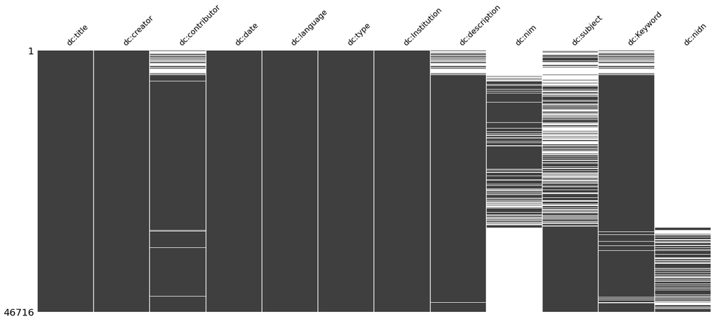

```python
msno.matrix(data, sparkline=False);
```

*Hati-hati, tampilan ini hanya mengecek data `None`. Setidaknya, ada beberapa (tidak sedikit tentunya) data `creator`, `description`, `subject` yang hanya berisi sedikit karakter (misal, kurang dari 4)*

### Cleaning Tahap Dua

Pertama, mari kita hilangkan `dc:` dari setiap *key* di data

```python
mapper = {x:x[3:] for x in items}
data = data.rename(columns=mapper)
```

```python
set(data['type']), set(data['language']), set(data['Institution'])
```

```
({'Thesis'}, {'Indonesia'}, {'INSTITUTE TEKNOLOGI BANDUNG'})
```

```python
data.drop(['type', 'language', 'Institution'], axis=1, inplace=True)
```

Ada beberapa *cleaning* lebih lanjut yang dapat dilakukan terhadap data ini, dari merapikan isi `contributor`, memperbaiki *typo* di `subject`, dsb. Namun saya memilih tidak melakukan hal tersebut (karena melelahkan).

### Analisis

Dari data terlihat beberapa revisi *yang sepertinya* terjadi dalam proses pencatatan data di Digilib ITB. Pertama adalah masa saat data yang dimasukkan tanpa protokol yang tegas (banyaknya data pada kolom `kontributor` dan `description` yang kosong). Masa yang kedua terjadi saat format penulisan `creator` perlu mengikutsertakan data NIM. Dan masa terakhir (saat ini), adalah masa penulisan `creator` tidak mengikutkan data NIM, dan diperkenalkannya kolom data `nidn`.

Keadaan seperti ini, tentunya akan menantang ketika kita mencoba mengumpulkan data skripsi mahasiswa suatu jurusan (pencarian berdasarkan NIM tidak cukup).

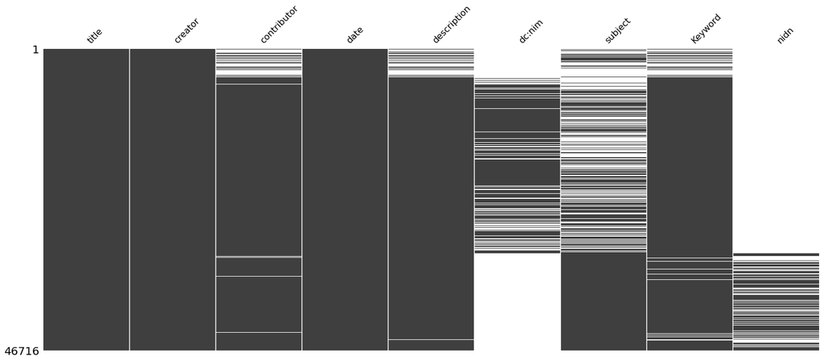

```python
msno.matrix(data, sparkline=False);
```

## Simpan Hasil

Saya menyimpan data dalam bentuk TSV (Tab Separated Value). Hal ini dapat dilakukan dengan cara

```python
data.to_csv("digilib.tsv", sep="\t")
```